# CCPS 844 Data Mining Project

#### By: Jaculine Medley Dec. 11, 2020

Introduction

Data Summary

Importing libraries and Titanic Dataset

Data Cleaning

Explorartory Analysis - Visualization of Data

Exportatory Analysis - K-Means and Hierarchical Clustering

Feature Engineering and PCA Dimension Reduction

Classification Algorithms

Concluding Evaluation of Classification Models

Regression Algorithms

Concluding Evaluation of Regression Models

Final Conclusion

## **Introduction**

This project is the datamining analysis on the RMS Titanic dataset.

The Titanic was a ship that attempted to sailed with passengers from Southampton, England to New York, USA. The RMS Titanic did not complete its voyage as it hit an iceberg and sank to the bottom of the Atlantic Ocean on April 15, 1912.

The following algoritms will be applied to the Titanic dataset.  
Classification Algorithms:

- Decision Tree Algorithm
- Naïve Bayes
- K-Nearest Neighbor
- Logistic Regression
- SVM Classification
- Kernel SVM
- Random Forest Classification

Regression Algoritihms:

- Linear Regression
- K-Nearest Neighbor
- SVM Regression
- Kernel SVM

In this exercise we will try to determine the following:

Which of the classification models and regression models used performed the best in predicting the probability of survival or non-survival from the Titanic?

Did any one or more features play a contributing factor in the probability of survival?

## **Data Summary**

The Titanic dataset was taken from the following source: https://data.world/nrippner/titanic-disaster-dataset

As well, the description, summary and features below have been taken directly from the same source.

#### *Description*

Classic dataset on Titanic disaster used often for data mining tutorials and demonstrations

#### *Summary*

This is a classic dataset used in many data mining tutorials and demos -- perfect for getting started with exploratory analysis and building binary classification models to predict survival.

Data covers passengers only, not crew.

#### *Features*

1. survival - Survival (0 = No; 1 = Yes)
2. class - Passenger Class (1 = 1st; 2 = 2nd; 3 = 3rd)
3. name - Name
4. sex - Sex
5. age - Age
6. sibsp - Number of Siblings/Spouses Aboard
7. parch - Number of Parents/Children Aboard
8. ticket - Ticket Number
9. fare - Passenger Fare
10. cabin - Cabin
11. embarked - Port of Embarkation (C = Cherbourg; Q = Queenstown; S = Southampton)
12. boat - Lifeboat (if survived)
13. body - Body number (if did not survive and body was recovered)

## Importing Libraries and Titanic Dataset

We begin by importing some of the libraries that we will be using and will rely heavily on throughout this analysis.

While the dataset has been included with this analysis for ease of reference, it is publically available at https://data.world/nrippner/titanic-disaster-dataset.

```python
#import important libraries
import pandas as pd
import numpy as np
import matplotlib.pyplot as plt
import seaborn as sns
from sklearn import metrics
%matplotlib inline
```

```python
#import the dataset
data = pd.read_csv('titanic.csv', sep= ',')
```

```python
print( "Dataset Length:: ", len(data))
print ("Dataset Shape:: ", data.shape)
```

```
Dataset Length::  1310
Dataset Shape::  (1310, 14)
```

```python
data.head()
```

|  | pclass | survived | name | sex | age | sibsp | parch | ticket | fare | cabin | embarked | boat | body | home.dest |
| --- | --- | --- | --- | --- | --- | --- | --- | --- | --- | --- | --- | --- | --- | --- |
| 0 | 1.0 | 1.0 | Allen, Miss. Elisabeth Walton | female | 29.0000 | 0.0 | 0.0 | 24160 | 211.3375 | B5 | S | 2 | NaN | St Louis, MO |
| 1 | 1.0 | 1.0 | Allison, Master. Hudson Trevor | male | 0.9167 | 1.0 | 2.0 | 113781 | 151.5500 | C22 C26 | S | 11 | NaN | Montreal, PQ / Chesterville, ON |
| 2 | 1.0 | 0.0 | Allison, Miss. Helen Loraine | female | 2.0000 | 1.0 | 2.0 | 113781 | 151.5500 | C22 C26 | S | NaN | NaN | Montreal, PQ / Chesterville, ON |
| 3 | 1.0 | 0.0 | Allison, Mr. Hudson Joshua Creighton | male | 30.0000 | 1.0 | 2.0 | 113781 | 151.5500 | C22 C26 | S | NaN | 135.0 | Montreal, PQ / Chesterville, ON |
| 4 | 1.0 | 0.0 | Allison, Mrs. Hudson J C (Bessie Waldo Daniels) | female | 25.0000 | 1.0 | 2.0 | 113781 | 151.5500 | C22 C26 | S | NaN | NaN | Montreal, PQ / Chesterville, ON |

## **Data Cleaning**

To clean the data we begin by dropping the columns name, cabin, home.dest, ticket and body as these features are irrelevant to the analysis. We converted categorical features to numeric form, filled in empty cells and deleted empty rows of data.

```python
# move the survived coloumn to the last column position.
# removed columns not relevant to our project (name, cabin, and home-dest, ticket).
data.insert(len(data.columns)-1, 'survived', data.pop('survived'))
data.pop('name')
data.pop('cabin')
data.pop('home.dest')
data.pop('ticket')
data.pop('body')
data.head()
```

|  | pclass | sex | age | sibsp | parch | fare | embarked | boat | survived |
| --- | --- | --- | --- | --- | --- | --- | --- | --- | --- |
| 0 | 1.0 | female | 29.0000 | 0.0 | 0.0 | 211.3375 | S | 2 | 1.0 |
| 1 | 1.0 | male | 0.9167 | 1.0 | 2.0 | 151.5500 | S | 11 | 1.0 |
| 2 | 1.0 | female | 2.0000 | 1.0 | 2.0 | 151.5500 | S | NaN | 0.0 |
| 3 | 1.0 | male | 30.0000 | 1.0 | 2.0 | 151.5500 | S | NaN | 0.0 |
| 4 | 1.0 | female | 25.0000 | 1.0 | 2.0 | 151.5500 | S | NaN | 0.0 |

```python
# get information about the dataset
data.info()
```

```
<class 'pandas.core.frame.DataFrame'>
RangeIndex: 1310 entries, 0 to 1309
Data columns (total 9 columns):
 #   Column    Non-Null Count  Dtype
---  ------    --------------  -----
 0   pclass    1309 non-null   float64
 1   sex       1309 non-null   object
 2   age       1046 non-null   float64
 3   sibsp     1309 non-null   float64
 4   parch     1309 non-null   float64
 5   fare      1308 non-null   float64
 6   embarked  1307 non-null   object
 7   boat      486 non-null    object
 8   survived  1309 non-null   float64
dtypes: float64(6), object(3)
memory usage: 92.2+ KB
```

```python
# check if there are any missing values
print(data.isna().sum())
```

```
pclass        1
sex           1
age         264
sibsp         1
parch         1
fare          2
embarked      3
boat        824
survived      1
dtype: int64
```

```python
# fill the empty cells in the age column with the average age of the passengers
import math
avgAge = math.modf(data['age'].mean())[1]
data['age'] = data['age'].fillna(avgAge)
data['age']
```

```
0       29.0000
1        0.9167
2        2.0000
3       30.0000
4       25.0000
         ...
1305    29.0000
1306    26.5000
1307    27.0000
1308    29.0000
1309    29.0000
Name: age, Length: 1310, dtype: float64
```

```python
# as there is a large range of ages, we'll divide the ages into groups which may be easier to work with.
data.insert(3, 'ageGroup', 0.0)

for item in data:
   # item['ageGroup'] = data['ageGroup'].astype(float)
    data.loc[ data['age'] <= 11, 'ageGroup'] = 0.0
    data.loc[(data['age'] > 11) & (data['age'] <= 19), 'ageGroup'] = 1.0
    data.loc[(data['age'] > 19) & (data['age'] <= 29), 'ageGroup'] = 2.0
    data.loc[(data['age'] > 29) & (data['age'] <= 39), 'ageGroup'] = 3.0
    data.loc[(data['age'] > 39) & (data['age'] <= 49), 'ageGroup'] = 4.0
    data.loc[(data['age'] > 49) & (data['age'] <= 59), 'ageGroup'] = 5.0
    data.loc[(data['age'] > 59) & (data['age'] <= 69), 'ageGroup'] = 6.0
    data.loc[(data['age'] > 69) & (data['age'] <= 79), 'ageGroup'] = 7.0
    data.loc[(data['age'] > 79) & (data['age'] <= 99), 'ageGroup'] = 8.0
    data.loc[ data['age'] > 99, 'age'] = 9.0
```

```python
# find which cells are empty in the embark column
data[data['embarked'].isnull()].index
```

```
Int64Index([168, 284, 1309], dtype='int64')
```

Source for code used to determing empty cells on line 10: https://stackoverflow.com/questions/27159189/find-empty-or-nan-entry-in-pandas-dataframe

```python
# there are three empyty rows in the emabrked column.
# as there are three dictinct values for embarked we will fill the empty rows in the embarked column
# with 'S', 'C' and 'Q' respectively as not to overweight one classification for embarked.
data.at[168, 'embarked']= 'S'
data.at[284, 'embarked']= 'C'
data.at[1309, 'embarked']= 'Q'
```

```python
# there were only two missing fares. We will fill in those two empty cells
# with the average fare paid by all the passengers.
import math
avgFare = math.modf(data['fare'].mean())[1]
data['fare'] = data['fare'].fillna(avgFare)
```

```python
# check again if there are any missing values
print(data.isna().sum())
```

```
pclass        1
sex           1
age           0
ageGroup      0
sibsp         1
parch         1
fare          0
embarked      0
boat        824
survived      1
dtype: int64
```

```python
data.iloc[50:60, :]
```

|  | pclass | sex | age | ageGroup | sibsp | parch | fare | embarked | boat | survived |
| --- | --- | --- | --- | --- | --- | --- | --- | --- | --- | --- |
| 50 | 1.0 | female | 58.0 | 5.0 | 0.0 | 1.0 | 512.3292 | C | 3 | 1.0 |
| 51 | 1.0 | male | 33.0 | 3.0 | 0.0 | 0.0 | 5.0000 | S | NaN | 0.0 |
| 52 | 1.0 | male | 28.0 | 2.0 | 0.0 | 0.0 | 47.1000 | S | NaN | 0.0 |
| 53 | 1.0 | male | 17.0 | 1.0 | 0.0 | 0.0 | 47.1000 | S | NaN | 0.0 |
| 54 | 1.0 | male | 11.0 | 0.0 | 1.0 | 2.0 | 120.0000 | S | 4 | 1.0 |
| 55 | 1.0 | female | 14.0 | 1.0 | 1.0 | 2.0 | 120.0000 | S | 4 | 1.0 |
| 56 | 1.0 | male | 36.0 | 3.0 | 1.0 | 2.0 | 120.0000 | S | C | 1.0 |
| 57 | 1.0 | female | 36.0 | 3.0 | 1.0 | 2.0 | 120.0000 | S | 4 | 1.0 |
| 58 | 1.0 | male | 49.0 | 4.0 | 0.0 | 0.0 | 26.0000 | S | NaN | 0.0 |
| 59 | 1.0 | female | 29.0 | 2.0 | 0.0 | 0.0 | 27.7208 | C | 5 | 1.0 |

```python
# convert the boats to numerical numbers
boatNumber = {"1": 1.0, "2": 2.0, "3": 3.0, "4": 4.0, "5": 5.0, "6": 6.0, "7": 7.0, "8": 8.0, "9": 9.0, "10": 10.0, "11": 11.0, "12": 12.0, "13": 13.0, "14": 14.0, "A": 99.0, "B": 95.0, "C": 89.0, "D": 85.0}

for item in [data]:
    item['boat'] = item['boat'].map(boatNumber)
```

```python
# fill NaN cells in the boat column
data['boat'] = data['boat'].fillna(0)
```

```python
# check that the NaN were sucessfully filled
data.iloc[50:60, :]
```

|  | pclass | sex | age | ageGroup | sibsp | parch | fare | embarked | boat | survived |
| --- | --- | --- | --- | --- | --- | --- | --- | --- | --- | --- |
| 50 | 1.0 | female | 58.0 | 5.0 | 0.0 | 1.0 | 512.3292 | C | 3.0 | 1.0 |
| 51 | 1.0 | male | 33.0 | 3.0 | 0.0 | 0.0 | 5.0000 | S | 0.0 | 0.0 |
| 52 | 1.0 | male | 28.0 | 2.0 | 0.0 | 0.0 | 47.1000 | S | 0.0 | 0.0 |
| 53 | 1.0 | male | 17.0 | 1.0 | 0.0 | 0.0 | 47.1000 | S | 0.0 | 0.0 |
| 54 | 1.0 | male | 11.0 | 0.0 | 1.0 | 2.0 | 120.0000 | S | 4.0 | 1.0 |
| 55 | 1.0 | female | 14.0 | 1.0 | 1.0 | 2.0 | 120.0000 | S | 4.0 | 1.0 |
| 56 | 1.0 | male | 36.0 | 3.0 | 1.0 | 2.0 | 120.0000 | S | 89.0 | 1.0 |
| 57 | 1.0 | female | 36.0 | 3.0 | 1.0 | 2.0 | 120.0000 | S | 4.0 | 1.0 |
| 58 | 1.0 | male | 49.0 | 4.0 | 0.0 | 0.0 | 26.0000 | S | 0.0 | 0.0 |
| 59 | 1.0 | female | 29.0 | 2.0 | 0.0 | 0.0 | 27.7208 | C | 5.0 | 1.0 |

```python
# drop any remaining rows with missing values
data.dropna(inplace=True)
```

```python
# check for any remaining missing values
print(data.isna().sum())
```

```
pclass      0
sex         0
age         0
ageGroup    0
sibsp       0
parch       0
fare        0
embarked    0
boat        0
survived    0
dtype: int64
```

## **Exploratory Analysis - Visualization of Data**

```python
data.describe()
```

|  | pclass | age | ageGroup | sibsp | parch | fare | boat | survived |
| --- | --- | --- | --- | --- | --- | --- | --- | --- |
| count | 1309.000000 | 1309.00000 | 1309.000000 | 1309.000000 | 1309.000000 | 1309.000000 | 1309.000000 | 1309.000000 |
| mean | 2.294882 | 29.70410 | 2.432391 | 0.498854 | 0.385027 | 33.295254 | 7.521772 | 0.381971 |
| std | 0.837836 | 12.88804 | 1.347573 | 1.041658 | 0.865560 | 51.738880 | 21.220422 | 0.486055 |
| min | 1.000000 | 0.16670 | 0.000000 | 0.000000 | 0.000000 | 0.000000 | 0.000000 | 0.000000 |
| 25% | 2.000000 | 22.00000 | 2.000000 | 0.000000 | 0.000000 | 7.895800 | 0.000000 | 0.000000 |
| 50% | 3.000000 | 29.00000 | 2.000000 | 0.000000 | 0.000000 | 14.454200 | 0.000000 | 0.000000 |
| 75% | 3.000000 | 35.00000 | 3.000000 | 1.000000 | 0.000000 | 31.275000 | 5.000000 | 1.000000 |
| max | 3.000000 | 80.00000 | 8.000000 | 8.000000 | 9.000000 | 512.329200 | 99.000000 | 1.000000 |

#### *Visualizations of the Data*

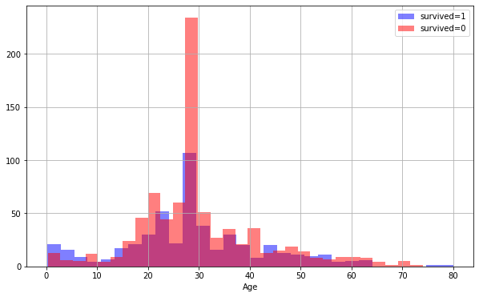

```python
plt.figure(figsize=(10,6))
data[data['survived']==1]['age'].hist(alpha=0.5,color='blue',
                                              bins=30,label='survived=1')
data[data['survived']==0]['age'].hist(alpha=0.5,color='red',
                                              bins=30,label='survived=0')
plt.legend()
plt.xlabel('Age')
```

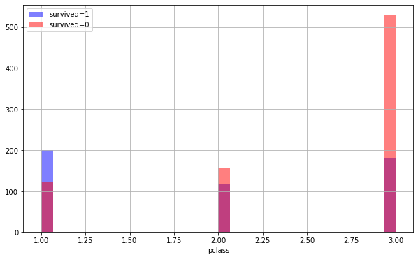

```python
plt.figure(figsize=(10,6))
data[data['survived']==1]['pclass'].hist(alpha=0.5,color='blue',
                                              bins=30,label='survived=1')
data[data['survived']==0]['pclass'].hist(alpha=0.5,color='red',
                                              bins=30,label='survived=0')
plt.legend()
plt.xlabel('pclass')
```

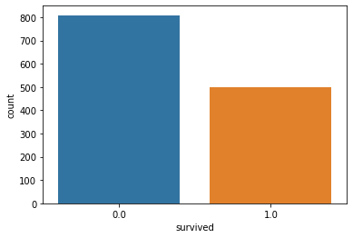

```python
sns.countplot(data['survived'])
```

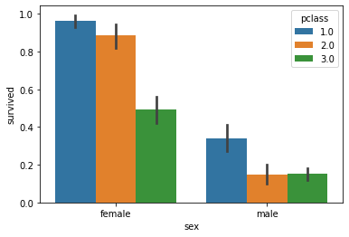

```python
sns.barplot(x="sex", y="survived",
            hue="pclass", data=data);
```

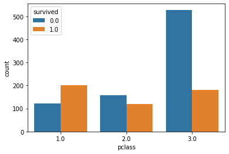

```python
sns.countplot(x="pclass",data=data,hue="survived")
```

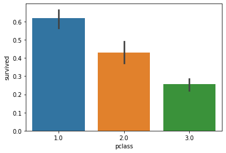

```python
sns.barplot(x='pclass', y='survived', data=data)
```

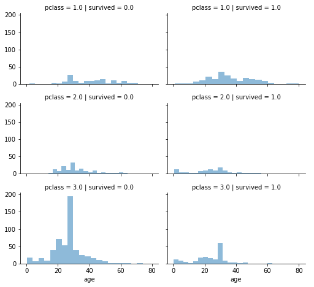

```python
sns.FacetGrid(data, col='survived', row='pclass', size=2.2, aspect=1.6).map(plt.hist, 'age', alpha=.5, bins=20).add_legend();
```

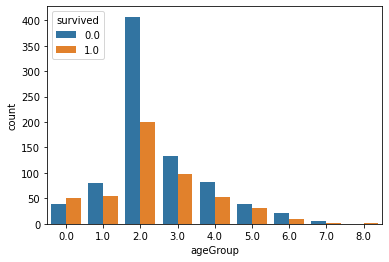

```python
sns.countplot(x="ageGroup",data=data,hue="survived")
```

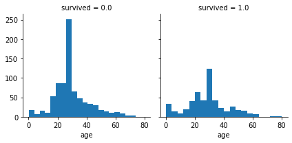

```python
sns.FacetGrid(data, col='survived').map(plt.hist, 'age', bins=20)
```

The code to run the above chart was taken from an internet resource that I did not adequately note and therefore cannot properly attribute.  
Source for code: unknown.

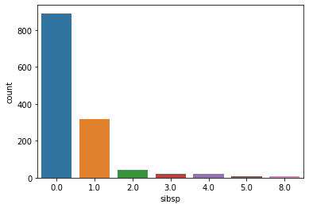

```python
sns.countplot(x='sibsp',data=data) # count based on sibling or spouse
```

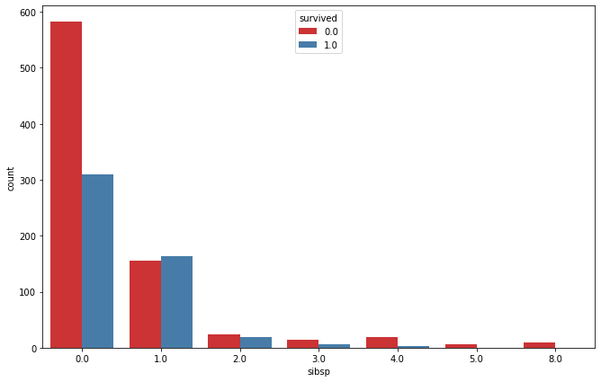

```python
plt.figure(figsize=(11,7))
sns.countplot(x='sibsp',hue='survived',data=data,palette='Set1')
```

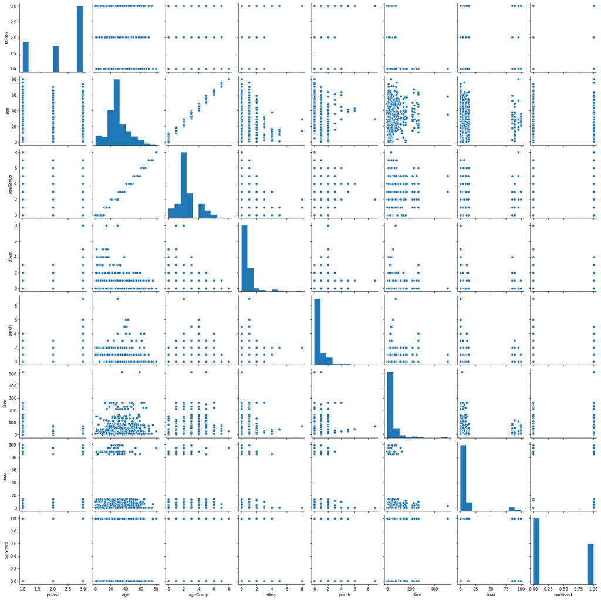

```python
sns.pairplot(data)
```

```python
# see if there are any correlations in the data
data.corr()
```

|  | pclass | age | ageGroup | sibsp | parch | fare | boat | survived |
| --- | --- | --- | --- | --- | --- | --- | --- | --- |
| pclass | 1.000000 | -0.371938 | -0.381843 | 0.060832 | 0.018322 | -0.558481 | 0.014474 | -0.312469 |
| age | -0.371938 | 1.000000 | 0.971293 | -0.190465 | -0.128573 | 0.175025 | -0.076196 | -0.047227 |
| ageGroup | -0.381843 | 0.971293 | 1.000000 | -0.190818 | -0.119899 | 0.177128 | -0.076766 | -0.028242 |
| sibsp | 0.060832 | -0.190465 | -0.190818 | 1.000000 | 0.373587 | 0.160226 | -0.018114 | -0.027825 |
| parch | 0.018322 | -0.128573 | -0.119899 | 0.373587 | 1.000000 | 0.221524 | 0.024850 | 0.082660 |
| fare | -0.558481 | 0.175025 | 0.177128 | 0.160226 | 0.221524 | 1.000000 | -0.011674 | 0.244211 |
| boat | 0.014474 | -0.076196 | -0.076766 | -0.018114 | 0.024850 | -0.011674 | 1.000000 | 0.399828 |
| survived | -0.312469 | -0.047227 | -0.028242 | -0.027825 | 0.082660 | 0.244211 | 0.399828 | 1.000000 |

```python
# remove ageGroup as we only used it to simplify some of the visualizations.
data.pop('ageGroup')
```

```
0       2.0
1       0.0
2       0.0
3       3.0
4       2.0
       ...
1304    1.0
1305    2.0
1306    2.0
1307    2.0
1308    2.0
Name: ageGroup, Length: 1309, dtype: float64
```

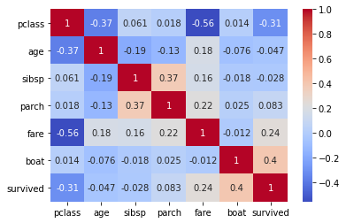

```python
# visualize the correlation matrix
sns.heatmap(data.corr(),cmap='coolwarm',annot=True)
```

There are no strong positive or negative correlations between any of the features in the dataset. The majority of the correlation coeeficients are near zero indicating that the features are independent of each other.

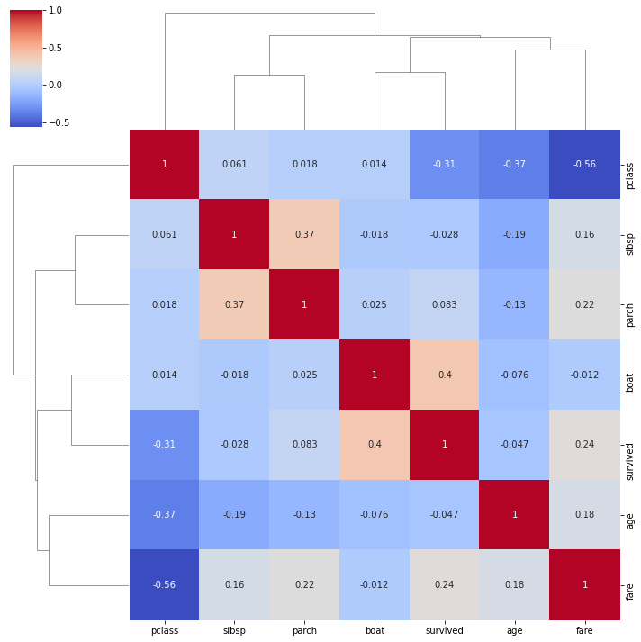

```python
# cluster correlation chart
sns.clustermap(data.corr(),cmap='coolwarm',annot=True)
```

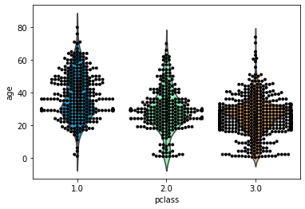

```python
sns.violinplot(data=data, x="pclass", y="age",
               palette='rainbow')#
sns.swarmplot(data=data, x="pclass", y="age",
              color = 'black',size=4)#size=4 size of dots
```

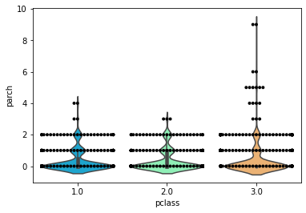

```python
sns.violinplot(data=data, x="pclass", y="parch",
               palette='rainbow')#
sns.swarmplot(data=data, x="pclass", y="parch",
              color = 'black',size=4)#size=4 size of dots
```

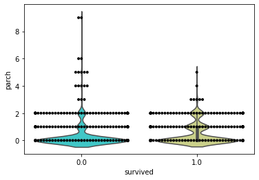

```python
sns.violinplot(data=data, x="survived", y="parch",
               palette='rainbow')#
sns.swarmplot(data=data, x="survived", y="parch",
              color = 'black',size=4)#size=4 size of dots
```

## **Exploratory Analysis - K-Means & Hierarchical Clustering**

```python
# convert any remaining categories to numerical values in order to run algorithms
```

```python
# convert the embarkerd ports to numerical numbers
ports = {"S": 1.0, "C": 2.0, "Q": 3.0}

for item in [data]:
    item['embarked'] = item['embarked'].map(ports)
```

```python
# converting sex categories to nuerical values
genders = {"male": 0.0, "female": 1.0}

for item in [data]:
    item['sex'] = item['sex'].map(genders)
```

```python
# check that the remaining categories were converted to numerical
data.head()
```

|  | pclass | sex | age | sibsp | parch | fare | embarked | boat | survived |
| --- | --- | --- | --- | --- | --- | --- | --- | --- | --- |
| 0 | 1.0 | 1.0 | 29.0000 | 0.0 | 0.0 | 211.3375 | 1.0 | 2.0 | 1.0 |
| 1 | 1.0 | 0.0 | 0.9167 | 1.0 | 2.0 | 151.5500 | 1.0 | 11.0 | 1.0 |
| 2 | 1.0 | 1.0 | 2.0000 | 1.0 | 2.0 | 151.5500 | 1.0 | 0.0 | 0.0 |
| 3 | 1.0 | 0.0 | 30.0000 | 1.0 | 2.0 | 151.5500 | 1.0 | 0.0 | 0.0 |
| 4 | 1.0 | 1.0 | 25.0000 | 1.0 | 2.0 | 151.5500 | 1.0 | 0.0 | 0.0 |

#### *K-Means Clustering*

We will choose the age and boat column as the features to use in performing the KMean algorithm. These two features were arbitrarily chosen and there is no evidence to support the selection of these two features over a different pair of features.

```python
# allocate data to X and y variables.
Xk = data.loc[:, ['age','boat']].to_numpy()
y = np.array(data['survived'])
```

```python
# import KMeans
from sklearn.cluster import KMeans
```

We will begin by using the Elbow Method to determine the optimal number of clusters. The code below can be found at the following source: https://medium.com/@michellibelly/k-means-clustering-for-analysis-of-heart-disease-c2c6f75927e0

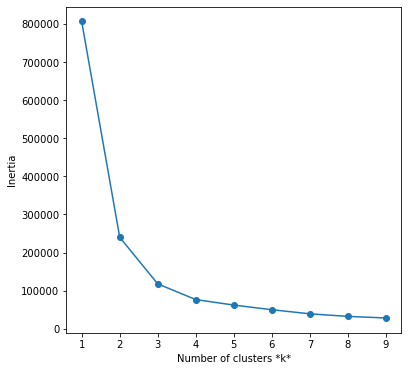

```python
# run the elbow method code
sse = []
list_k = list(range(1, 10))

for k in list_k:
    km = KMeans(n_clusters=k)
    km.fit(Xk)
    sse.append(km.inertia_)

# plot sse against k
plt.figure(figsize=(6, 6))
plt.plot(list_k, sse, '-o')
plt.xlabel(r'Number of clusters *k*')
plt.ylabel('Inertia');
```

From the Elbow method, it appears the optimal number of clusters to use is 3. However, because our target has two outcomes we will use run K-means with clusters of 2.

```python
# create the K-Means object with n_cluster = 2 and fit the model
kmeansModel = KMeans(n_clusters=2)
kmeansModel.fit(Xk)
```

```
KMeans(n_clusters=2)
```

```python
# determine the cluster centers
kmeansModel.cluster_centers_
```

```
array([[26.30128205, 90.07692308],
       [29.919713  ,  2.29082047]])
```

```python
# get the cluster labels
kmeansModel.labels_
```

```
array([1, 1, 1, ..., 1, 1, 1], dtype=int32)
```

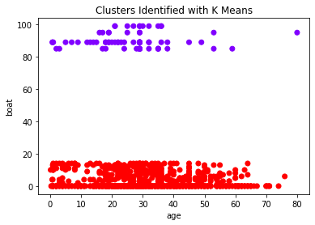

```python
# visualize the clusters
plt.scatter(Xk[:,0],Xk[:,1],c=kmeansModel.labels_,cmap='rainbow')
plt.title("Clusters Identified with K Means")
plt.xlabel('age')
plt.ylabel('boat')
plt.show()
```

We will apply the K-Means model to the original data to see if the predicted clusters are consistent with the actual clusters.

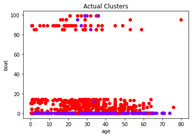

```python
# apply K-means to the original data
y = [data['survived']]
plt.scatter(Xk[:,0],Xk[:,1],c=y,cmap='rainbow')
plt.title("Actual Clusters")
plt.xlabel('age')
plt.ylabel('boat')
plt.show()
```

```python
# check the accuracy of our k-means algorithm
y = np.array(data['survived'])
correct = 0
for i in range(len(Xk)):
    predict_me = np.array(Xk[i].astype(float))
    predict_me = predict_me.reshape(-1, len(predict_me))
    prediction = kmeansModel.predict(predict_me)
    if prediction[0] == y[i]:
        correct += 1

print(correct/len(Xk))
```

```
0.3330786860198625
```

#### *Hierarchical Clustering*

In the exploratory analysis using hierarchical clustering, there are no clear justifications that would lead us to choose one linkage criteria over the other. Thus, we will run the algorithm with the following linkage criterium: complete, single and average, and examine the resulting visualizations.

```python
# import the hierarchial cluster library
from scipy.cluster.hierarchy import linkage, dendrogram
import matplotlib.pyplot as plt
# remove the survived column from the DataFrame
outcomes = list(data['survived'])
samples = data.values
```

```python
# perform hierarchical clustering on samples using the linkage() function with the method='complete' keyword argument. Assign the result to mergings
mergings = linkage(samples, method='complete')
```

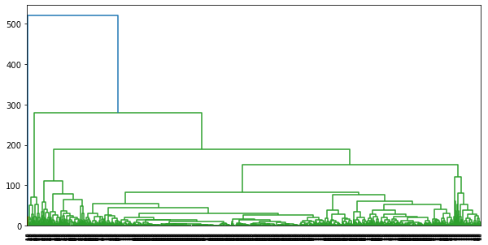

```python
# plot a dendrogram using the dendrogram() function on mergings, specifying the keyword arguments labels=outcomes, leaf_rotation=90, and leaf_font_size=6. Remember to call plt.show() afterwards, to display your plot.
plt.figure(figsize=(10, 5))
dendrogram(mergings,
           labels=outcomes,
           leaf_rotation=90,
           leaf_font_size=6,
)
plt.show()
```

```python
# use single link method to calculate the mergings and plot the dendrogram
singles = linkage(samples, method='single')
```

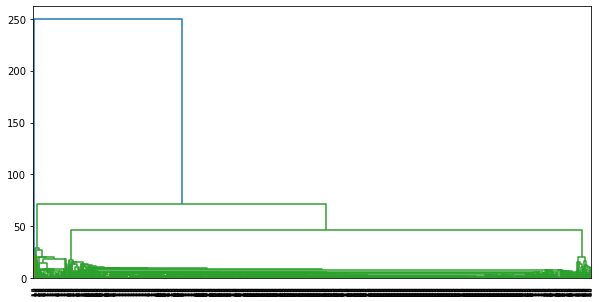

```python
plt.figure(figsize=(10, 5))
dendrogram(singles,
           labels=outcomes,
           leaf_rotation=90,
           leaf_font_size=6,
)
plt.show()
```

```python
# use single link method to calculate the mergings and plot the dendrogram
average = linkage(samples, method='average')
```

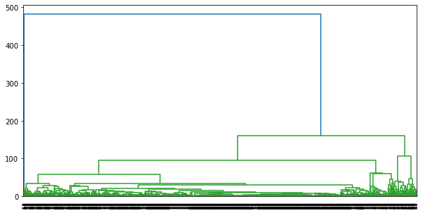

```python
# the first line sets the size of your plot
plt.figure(figsize=(10, 5))
dendrogram(average,
           labels=outcomes,
           leaf_rotation=90,
           leaf_font_size=6,
)
plt.figure(figsize=(30,40))
plt.show()
```

The resulting dendrogram of the hierarchical algorithm for each of the linkage criteria appear to be skewed. We will try to normalize the data and re-run the hierarchical clustering to see if we get better visualization results.

```python
# import the normalize library
from sklearn.preprocessing import normalize
```

```python
# rescale the data by using the normalize() function on the data
normalized_samples = normalize(samples)
```

```python
# apply the linkage() function to normalized_samples, using 'complete' linkage, to calculate the hierarchical clusterin
mergings = linkage(normalized_samples, method='complete')
```

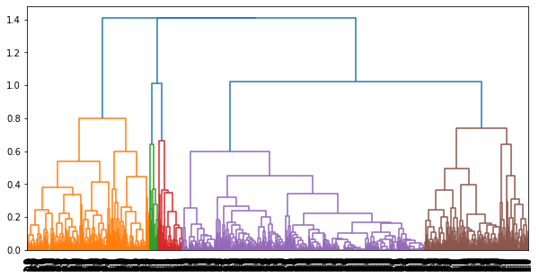

```python
# the first line sets the size of your plot
plt.figure(figsize=(10, 5))

dendrogram(
    mergings,
    labels=outcomes,
    leaf_rotation=90,
    leaf_font_size=10
)
plt.show()
```

```python
# apply the linkage() function to normalized_samples, using 'single' linkage, to calculate the hierarchical clusterin
sing_mergings = linkage(normalized_samples, method='single')
```

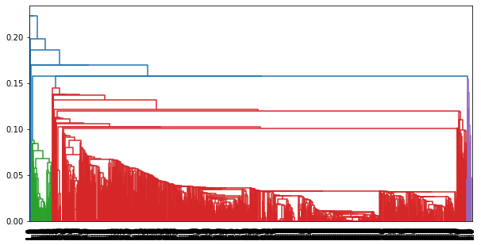

```python
# the first line sets the size of your plot
plt.figure(figsize=(10, 5))

dendrogram(
    sing_mergings,
    labels=outcomes,
    leaf_rotation=90,
    leaf_font_size=10
)
plt.show()
```

```python
# apply the linkage() function to normalized_samples, using 'average' linkage, to calculate the hierarchical clusterin
avg_mergings = linkage(normalized_samples, method='average')
```

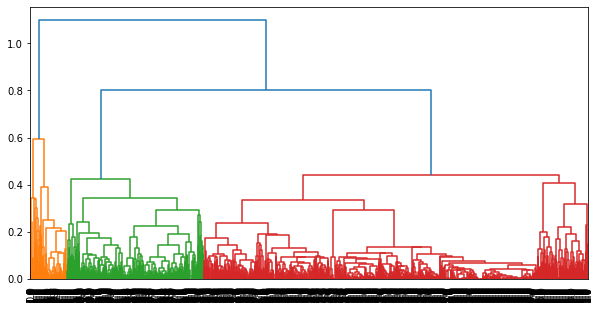

```python
# the first line sets the size of your plot
plt.figure(figsize=(10, 5))

dendrogram(
    avg_mergings,
    labels=outcomes,
    leaf_rotation=90,
    leaf_font_size=10
)
plt.show()
```

From the dendrogram, it appears that the optimal number clusters is 3. This is consistent with the findings of the K-means clustering analysis.

We will now obtain a flat clustering by using the fcluster() function on mergings, specifying a maximum height of 1.3 and the keyword argument criterion='distance', and will display the predicted outcomes.

```python
from scipy.cluster.hierarchy import fcluster
```

```python
labels = fcluster(mergings, 1.3, criterion='distance')
```

```python
df = pd.DataFrame({'labels': labels, 'outcomes': outcomes})
```

```python
ct = pd.crosstab(df['labels'], df['outcomes'])
ct
```

| outcomes labels | 0.0 | 1.0 |
| --- | --- | --- |
| 1 | 137 | 183 |
| 2 | 7 | 79 |
| 3 | 665 | 238 |

## **Feature Engineering and PCA Dimension Reduction**

Our correlation matrix showed us that the features are mostly independent. We will now attempt to determine to what extent did any of the features play in the survival probalilty of the passengers on the Titanic.

To ascertain what features are non-important, we will use Recursive Feature Elimination with estimators: Logistic Regression, Random Forest and Decision Tree. We will then use Recursive Feature Elimination followed by PCA Dimension Reduction.

```python
# import feature engineering libraries
from sklearn.svm import SVC
from sklearn.model_selection import StratifiedKFold
from sklearn.feature_selection import RFECV
from sklearn.datasets import make_classification
%matplotlib inline
```

```python
# allocate data to X and y variables
X = data.drop('survived',axis=1).astype(float)
y = data['survived']
```

#### *RFECV using Logistic Regression as the Classifier*

```python
# create the RFE object and compute a cross-validated score.
from sklearn.linear_model import LogisticRegression
logit=LogisticRegression(multi_class='ovr',solver='lbfgs', max_iter=5000)
```

```python
# the "accuracy" scoring is proportional to the number of correct
# classifications
rfecv = RFECV(estimator=logit, step=1, cv=StratifiedKFold(10), scoring='accuracy')
rfecv.fit(X, y)

print(f"Optimal number of features : {rfecv.n_features_}")
```

```
Optimal number of features : 5
```

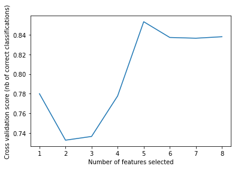

```python
# plot number of features VS. cross-validation scores
plt.figure()
plt.xlabel("Number of features selected")
plt.ylabel("Cross validation score (nb of correct classifications)")
plt.plot(range(1, len(rfecv.grid_scores_) + 1), rfecv.grid_scores_)
plt.show()
```

```python
rfecv.support_
```

```
array([ True,  True, False,  True, False, False,  True,  True])
```

```python
rfecv.ranking_
```

```
array([1, 1, 2, 1, 3, 4, 1, 1])
```

```python
names = data.columns
print("Features sorted by their rank:")
print(sorted(zip(map(lambda x: round(x, 4), rfecv.ranking_), names)))
```

```
Features sorted by their rank:
[(1, 'boat'), (1, 'embarked'), (1, 'pclass'), (1, 'sex'), (1, 'sibsp'), (2, 'age'), (3, 'parch'), (4, 'fare')]
```

Source for the code to sort the features by their rank in line 79: https://blog.datadive.net/selecting-good-features-part-iv-stability-selection-rfe-and-everything-side-by-side/

Running RFECV with the logistic regression estimator determined that there are 5 optimal features that contributed to the probability of survival of the passengers. Those features are: boat, embarked, pclass, sex and sibsp. So, whether the passenger was able to get on a boat, the place where they embarked on their voyage, their social status, whether they were male or female and had a sibling with then on the voyage, all factored into the passenger chances of survival.

#### *RFECV using Random Forest as the estimator*

```python
# allocate data to X and y variables
X = data.drop('survived',axis=1).astype(float)
y = data['survived']
```

```python
# create the RFE object and compute a cross-validated score.
from sklearn.ensemble import RandomForestClassifier
rfc = RandomForestClassifier(n_estimators=600)
# the "accuracy" scoring is proportional to the number of correct
# classifications
rfecvRFC = RFECV(estimator=rfc, step=1, cv=StratifiedKFold(10), scoring='accuracy')
rfecvRFC.fit(X, y)

print(f"Optimal number of features : {rfecvRFC.n_features_}")
```

```
Optimal number of features : 1
```

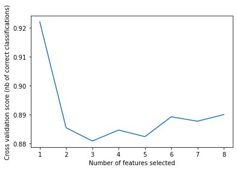

```python
# plot number of features VS. cross-validation scores
plt.figure()
plt.xlabel("Number of features selected")
plt.ylabel("Cross validation score (nb of correct classifications)")
plt.plot(range(1, len(rfecvRFC.grid_scores_) + 1), rfecvRFC.grid_scores_)
plt.show()
```

```python
rfecvRFC.support_
```

```
array([False, False, False, False, False, False, False,  True])
```

```python
rfecvRFC.ranking_
```

```
array([5, 3, 4, 6, 7, 2, 8, 1])
```

```python
# source code for ranking features: https://blog.datadive.net/selecting-good-features-part-iv-stability-selection-rfe-and-everything-side-by-side/
names = data.columns
print("Features sorted by their rank:")
print(sorted(zip(map(lambda x: round(x, 4), rfecvRFC.ranking_), names)))
```

```
Features sorted by their rank:
[(1, 'boat'), (2, 'fare'), (3, 'sex'), (4, 'age'), (5, 'pclass'), (6, 'sibsp'), (7, 'parch'), (8, 'embarked')]
```

Running RFECV with the random forest estimator determined that there is 1 optimal features that contributed to the probability of survival of the passengers. That feature was whether or not the passenger was able to get on a lifeboat when the Titanic was sinking.

#### *RFECV using Decision Tree as the Classifier*

```python
# create the RFE object and compute a cross-validated score.
from sklearn.tree import DecisionTreeClassifier
dt = DecisionTreeClassifier(criterion='entropy')
# the "accuracy" scoring is proportional to the number of correct
# classifications
rfecvDT = RFECV(estimator=dt, step=1, cv=StratifiedKFold(10), scoring='accuracy')
rfecvDT.fit(X, y)

print(f"Optimal number of features : {rfecvDT.n_features_}")
```

```
Optimal number of features : 1
```

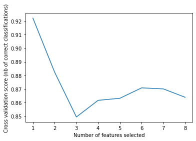

```python
# plot number of features VS. cross-validation scores
plt.figure()
plt.xlabel("Number of features selected")
plt.ylabel("Cross validation score (nb of correct classifications)")
plt.plot(range(1, len(rfecvDT.grid_scores_) + 1), rfecvDT.grid_scores_)
plt.show()
```

```python
rfecvDT.support_
```

```
array([False, False, False, False, False, False, False,  True])
```

```python
rfecvDT.ranking_
```

```
array([7, 4, 2, 6, 5, 3, 8, 1])
```

```python
# source code for ranking features: https://blog.datadive.net/selecting-good-features-part-iv-stability-selection-rfe-and-everything-side-by-side/
names = data.columns
print("Features sorted by their rank:")
print(sorted(zip(map(lambda x: round(x, 4), rfecvDT.ranking_), names)))
```

```
Features sorted by their rank:
[(1, 'boat'), (2, 'age'), (3, 'fare'), (4, 'sex'), (5, 'parch'), (6, 'sibsp'), (7, 'pclass'), (8, 'embarked')]
```

Running RFECV with the decision tree estimator also determined that there is 1 optimal features that contributed to the probability of survival of the passengers - whether the or not the passenger was able to get on a lifeboat.

#### *Recursive Feature Elimination*

```python
# import the libraries for RFE
from sklearn.svm import SVC
from sklearn.feature_selection import RFE
```

```python
# allocate data to X and y variables
X = data.drop('survived',axis=1).astype(float)
y = data['survived']
```

```python
# create the RFE object
svc = SVC(kernel="linear", C=1)
rfe = RFE(estimator=svc, n_features_to_select=1, step=1)
rfe.fit(X, y)
```

```
RFE(estimator=SVC(C=1, kernel='linear'), n_features_to_select=1)
```

```python
rfe.support_
```

```
array([False,  True, False, False, False, False, False, False])
```

```python
rfe.ranking_
```

```
array([3, 1, 7, 6, 5, 8, 2, 4])
```

```python
# source code for ranking features: https://blog.datadive.net/selecting-good-features-part-iv-stability-selection-rfe-and-everything-side-by-side/
names = data.columns
print("Features sorted by their rank:")
print(sorted(zip(map(lambda x: round(x, 4), rfe.ranking_), names)))
```

```
Features sorted by their rank:
[(1, 'sex'), (2, 'embarked'), (3, 'pclass'), (4, 'boat'), (5, 'parch'), (6, 'sibsp'), (7, 'age'), (8, 'fare')]
```

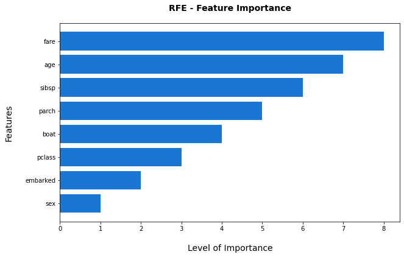

```python
# visualize the feature importance
names = data.columns
ranking = pd.DataFrame(sorted(zip(map(lambda x: round(x, 4), rfe.ranking_), names)))

plt.figure(figsize=(10, 6))
plt.barh(y=ranking[1], width=ranking[0], color='#1976D2')
plt.title('RFE - Feature Importance', fontsize=14, fontweight='bold', pad=20)
plt.xlabel('Level of Importance', fontsize=14, labelpad=20)
plt.ylabel('Features', fontsize=14, labelpad=20)
plt.show()
```

Running RFE determined that there was 1 optimal features that contributed to the probability of survival of the passengers - whether the passenger was male or female.

#### PCA Dimension Reduction

Using RFECV with logistic regression we had an optimal feature value of 5. Using RFECV with random forest and decision tree resulted in an optimal feature value of 1. As well, using RFE resulted in a optimal feature value of 1. We will use the results of the RFECV and RFE analysis as the basis for selecting the dimension reduction and will run the PCA with a dimension of 5 and then run the PCA with with a dimension of 1.

```python
# allocate data to X and y variables
X = data.drop('survived',axis=1).astype(int)
y = data['survived']
```

```python
# import decomposition library
# create pca object and fit the data with component = 5
from sklearn import decomposition
pca = decomposition.PCA(n_components=5)
pca.fit(X)
X_pca5 = pca.transform(X)
```

```python
# create pca object and fit the data with component = 5
pca = decomposition.PCA(n_components=1)
pca.fit(X)
X_pca1 = pca.transform(X)
```

## **Classification Algorithms**

We will run our classification algorithms based on the optimal features from the RFECV using the logistic regression estimator, then the RFECV with the random forest estimator, followed by RFECV with the decision tree estimator, RFE, PCA with component = 5 and PCA with component = 1. We will then compare the results of the algorithms to determine which produced the best results. While we will compare a number of scoring metrics, we will use the accuracy score as the basis for determining which algorithm and, its associated feature selections, performed the best.  
The classification algoritms that we will consider are as follows:

1. Decision Tree Algorithm
2. Naïve Bayes
3. K-Nearest Neighbor
4. Logistic Regression
5. SVM Classification
6. Kernel SVM
7. Random Forest Classification

We will evaluate the accuracy of each model by applying K-fold Cross Validation to the model.

We begin by creating a series of functions that when called will run the required algorithms.

#### *Create functions to define the classification and regression models/algorithms*

```python
# function that imports the algorithm classifier and creates the classifier object
def getModelObject(model):
    if(model == "Decision Tree"):
        # Decision Tree - we will use entropy to calculate the information gain
        from sklearn.tree import DecisionTreeClassifier
        # Create an instance of the classifier and fit the data to the model
        dtree = DecisionTreeClassifier(criterion='entropy')
        return dtree

    if(model == "Naives Bayes"):
        #import Naives Bayes, create the Naives Bayes object and fit the model
        from sklearn.naive_bayes import GaussianNB
        nb_clf = GaussianNB()
        return nb_clf

    if(model == "KNeighbor Classification"):
        from sklearn.neighbors import KNeighborsClassifier
        knn = KNeighborsClassifier(n_neighbors = 3)
        #fit the model
        return knn

    if(model == "Logistic Regression"):
        from sklearn.linear_model import LogisticRegression
        logreg = LogisticRegression(C=1.0, class_weight=None, dual=False, fit_intercept=True,
          intercept_scaling=1, max_iter=500, multi_class='ovr', n_jobs=1,
          penalty='l2', random_state=None, solver='liblinear', tol=0.0001,
          verbose=0, warm_start=False)
        return logreg

    if(model == "Random Forest"):
        from sklearn.ensemble import RandomForestClassifier
        rfc = RandomForestClassifier(n_estimators=600)
        return rfc

    if(model == "SVM Classifcation"):
        #import SVM and create a SVM object
        from sklearn import svm
        cl_svm = svm.SVC()
        return cl_svm

    if(model == "Kernel SVM Classification"):
        #import SVC from SVM and create a SVC object
        from sklearn import svm
        from sklearn.svm import SVC
        ksvmCl = SVC(kernel = 'linear', random_state = 0)
        return ksvmCl

    if(model == "Linear Regression"):
        #import linear regression and create a linear regression object
        from sklearn.linear_model import LinearRegression
        linreg = LinearRegression()
        return linreg

    if(model == "KNeighbor Regression"):
        #import KNN regression and create a KNN regression object
        from sklearn.neighbors import KNeighborsRegressor
        regknn = KNeighborsRegressor(n_neighbors=2)
        return regknn

    if(model == "SVM Regression"):
        #import SVM regression and create a SVM regression object
        from sklearn import svm
        rSvm = svm.SVR()
        return rSvm

    if(model == "Kernel SVM Regression"):
        #import Kernel SVM regression and create a Kernel SVM regression object
        from sklearn.svm import SVR
        kRegSvm = SVR(kernel = 'rbf',gamma='auto')
        return kRegSvm




# function that runs the Classification Algorithms and makes the predictions
def runClassModel(model, X, y):
    # split X and y into training and testing sets
    from sklearn.model_selection import train_test_split
    X_train, X_test, y_train, y_test = train_test_split(X, y, random_state=0)

    # get the calssifier object
    classifier = getModelObject(model)
    if(model == "SVM Kernel Classification"):
        # Feature scaling
        from sklearn.preprocessing import StandardScaler
        sc = StandardScaler()
        X_train = sc.fit_transform(X_train)
        X_test = sc.transform(X_test)
        # fit the model
        classifier.fit(X_train, y_train)
        #make class the predictions with the testing set
        predictions = classifier.predict(X_test)
        predictions = sc.inverse_transform(X_test)
        return predictions
    else:
        # fit the model
        classifier.fit(X_train, y_train)
        #make the class predictions for the testing set
        predictions = classifier.predict(X_test)
        return predictions




# function that runs the Regression Algorithms and makes the predictions
def runRegModel(model, X, y):
    # split X and y into training and testing sets
    from sklearn.model_selection import train_test_split
    X_train, X_test, y_train, y_test = train_test_split(X, y, random_state=0)

    # get the calssifier object
    classifier = getModelObject(model)
    # fit the model
    classifier.fit(X_train, y_train)
    # make prediction from the model
    predictions = classifier.predict(X_test)

    # print the intercept and coefficients
    if(model == "Linear Regression"):
        print(" Linear Regression intercept and coefficient:\n\n")
        print(classifier.intercept_)
        print(classifier.coef_)
        print("\n")
        # pair the feature names with the coefficients
        pd.DataFrame(classifier.coef_, X.columns, columns = ['Coeff'])

    return predictions
```

```python
# function that calculates and prints the results from the classification algortihms
def modelResults(model, predictions, y_test):
    from sklearn.metrics import classification_report,confusion_matrix
    print(model + " Confusion Matrix:")
    print(confusion_matrix(y_test,predictions))

    # format confusion matrix
    faceLabels = ['Not Survived (0)','Survived (1)']
    mat = confusion_matrix(y_test,predictions)
    sns.heatmap(mat.T, square=True, annot=True, fmt='d', cbar=False,
            xticklabels = faceLabels, cmap="BuPu", linecolor='black', linewidths=1,
            yticklabels = faceLabels)
    plt.xlabel('true label')
    plt.ylabel('predicted label');
    plt.show()
    print("\n")
    print("\n")
    print(model + " Classification Report:")
    print(classification_report(y_test,predictions))
    print("\n")
    print("\n")

# function that calculates and prints the results from the regression algortihms
def regModelResults(model, predictions, y_test):
    from sklearn import metrics
    from sklearn.metrics import r2_score

    # calculate MAE, MSE, RMSE
    print(model + " Error Calculations:\n")
    mae = metrics.mean_absolute_error(y_test, predictions)
    mse = metrics.mean_squared_error(y_test, predictions)
    rmse = np.sqrt(metrics.mean_squared_error(y_test, predictions))
    variance = r2_score(y_test, predictions)

    # print the results
    print(model + ' Variance score: %.2f' % variance)
    print(model + " MAE: : %.2f" % mae)
    print(model + " MSE: : %.2f" % mse)
    print(model + " RMSE: : %.2f" % rmse)
    print("\n")
```

```python
# function to evaluate the performance of the classification models using 10-fold cross validation
def evalClassModels(modelList):
    from matplotlib import pyplot
    from numpy import mean
    from numpy import std

    # declare variables to hold scores
    results, modelNames = list(), list()

    print("Mean accuracy score of classification models using 10-fold Cross-Validation:\n")

    for item in modelList:
        # get model classifier
        classifier = getModelObject(item)

        # 10-fold cross-validation
        from sklearn.model_selection import cross_val_score
        scores = cross_val_score(classifier, X, y, cv=10, scoring='accuracy')
        #add score to results list
        results.append(scores)
        modelNames.append(item)
        print('%s:  Mean-%.3f   Standard Deviation-(%.3f)' % (item, mean(scores), std(scores))) #Source: https://machinelearningmastery.com/rfe-feature-selection-in-python/

    # plot model performance for comparison. Code source: https://machinelearningmastery.com/rfe-feature-selection-in-python/
    plt.figure(figsize=(10,6))
    plt.boxplot(results, labels=modelNames, showmeans=True)
    plt.xticks(rotation=45)
    plt.title("Evaluation of Classification Models using 10-Fold Cross Evaluation")
    plt.show()


# function to evaluate performance of the regression models/algorithms using 10-fold cross validation
def evalRegModels(regModelList):
    from sklearn.model_selection import cross_val_score
    from numpy import mean

    #declare variables to hold scores
    regMseResults, regRMSEResults, regModelNames = list(), list(), list()

    print("Regression Model Metrics:\n")
    count = 0
    for item in regModelList:
        #get model classifier
        classifier = getModelObject(item)

        # 10-fold cross-validation with Linear Regression
        regScore = cross_val_score(classifier, X, y, cv=10, scoring='neg_mean_squared_error')
        mean_mse = -regScore.mean()
        regMseResults.append(mean_mse)
        regModelNames.append(item)
        # convert from MSE to RMSE
        mean_rmse = np.sqrt(mean_mse.mean())
        regRMSEResults.append(mean_rmse)

        #print results
        print("K-fold " + item + "MSE: %.2f" % mean_mse)
        print("K-fold " + item + "RMSE: %.2f" % mean_rmse)
        print("\n")
```

```python
# function to call and runs the classification algorithms and display model results when called
def callClassFunctions(X, y):
    import time
    #define Classification model variables
    DT = "Decision Tree"
    NB = "Naives Bayes"
    KNN = "KNeighbor Classification"
    LOGR = "Logistic Regression"
    RF = "Random Forest"
    SVMC = "SVM Classifcation"
    K_SVMC = "Kernel SVM Classification"

    dt_pred = runClassModel(DT, X, y)
    modelResults(DT, dt_pred, y_test)
    time.sleep(5)
    nb_pred = runClassModel(NB, X, y)
    modelResults(NB, nb_pred, y_test)
    time.sleep(5)
    knn_pred = runClassModel(KNN, X, y)
    modelResults(KNN, knn_pred, y_test)
    time.sleep(5)
    logr_pred = runClassModel(LOGR, X, y)
    modelResults(LOGR, logr_pred, y_test)
    time.sleep(5)
    rf_pred = runClassModel(RF, X, y)
    modelResults(RF, rf_pred, y_test)
    time.sleep(15)
    cl_svm_pred = runClassModel(SVMC, X, y)
    modelResults(SVMC, cl_svm_pred, y_test)
    time.sleep(5)
    ksvm_pred = runClassModel(K_SVMC, X, y)
    modelResults(K_SVMC, ksvm_pred, y_test)
    time.sleep(5)

# function to call and runs the regression algorithms and display model results when called
def callRegFunctions(X, y):
    import time
    #define Regression model variables
    LIN = "Linear Regression"
    REGKNN = "KNeighbor Regression"
    RSVM = "SVM Regression"
    K_RSVM = "Kernel SVM Regression"

    lin_pred = runRegModel(LIN, X, y)
    regModelResults(LIN, lin_pred, y_test)
    time.sleep(5)
    reg_Knn_pred = runClassModel(REGKNN, X, y)
    regModelResults(REGKNN, reg_Knn_pred, y_test)
    time.sleep(5)
    svmReg_pred = runClassModel(RSVM, X, y)
    regModelResults(RSVM, svmReg_pred, y_test)
    time.sleep(5)
    kerRSvm_pred = runClassModel(K_RSVM, X, y)
    regModelResults(K_RSVM, kerRSvm_pred, y_test)
    time.sleep(5)
```

```python
# allocate data to X and y variables.
X = data.loc[:, ['boat','embarked', 'pclass','sex', 'sibsp']]
y = data['survived']
```

```python
# split data into training and test sets
from sklearn.model_selection import train_test_split
X_train, X_test, y_train, y_test = train_test_split( X, y, test_size = 0.25, random_state = 100)
```

```
Decision Tree Confusion Matrix:
[[130  80]
 [ 82  36]]
```

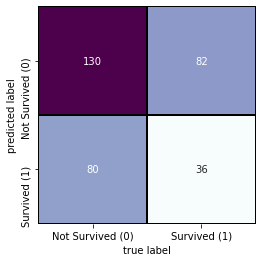

```
Decision Tree Classification Report:
              precision    recall  f1-score   support

         0.0       0.61      0.62      0.62       210
         1.0       0.31      0.31      0.31       118

    accuracy                           0.51       328
   macro avg       0.46      0.46      0.46       328
weighted avg       0.50      0.51      0.51       328





Naives Bayes Confusion Matrix:
[[146  64]
 [ 83  35]]
```

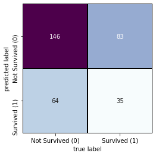

```
Naives Bayes Classification Report:
              precision    recall  f1-score   support

         0.0       0.64      0.70      0.67       210
         1.0       0.35      0.30      0.32       118

    accuracy                           0.55       328
   macro avg       0.50      0.50      0.49       328
weighted avg       0.54      0.55      0.54       328





KNeighbor Classification Confusion Matrix:
[[132  78]
 [ 86  32]]
```

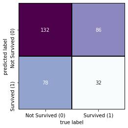

```
KNeighbor Classification Classification Report:
              precision    recall  f1-score   support

         0.0       0.61      0.63      0.62       210
         1.0       0.29      0.27      0.28       118

    accuracy                           0.50       328
   macro avg       0.45      0.45      0.45       328
weighted avg       0.49      0.50      0.50       328





Logistic Regression Confusion Matrix:
[[137  73]
 [ 82  36]]
```

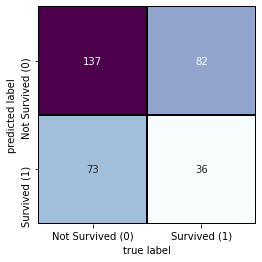

```
Logistic Regression Classification Report:
              precision    recall  f1-score   support

         0.0       0.63      0.65      0.64       210
         1.0       0.33      0.31      0.32       118

    accuracy                           0.53       328
   macro avg       0.48      0.48      0.48       328
weighted avg       0.52      0.53      0.52       328





Random Forest Confusion Matrix:
[[127  83]
 [ 82  36]]
```

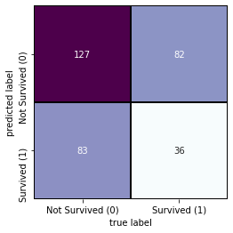

```
Random Forest Classification Report:
              precision    recall  f1-score   support

         0.0       0.61      0.60      0.61       210
         1.0       0.30      0.31      0.30       118

    accuracy                           0.50       328
   macro avg       0.46      0.45      0.46       328
weighted avg       0.50      0.50      0.50       328





SVM Classifcation Confusion Matrix:
[[141  69]
 [ 88  30]]
```

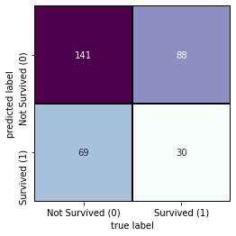

```
SVM Classifcation Classification Report:
              precision    recall  f1-score   support

         0.0       0.62      0.67      0.64       210
         1.0       0.30      0.25      0.28       118

    accuracy                           0.52       328
   macro avg       0.46      0.46      0.46       328
weighted avg       0.50      0.52      0.51       328





Kernel SVM Classification Confusion Matrix:
[[144  66]
 [ 89  29]]
```

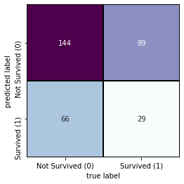

```
Kernel SVM Classification Classification Report:
              precision    recall  f1-score   support

         0.0       0.62      0.69      0.65       210
         1.0       0.31      0.25      0.27       118

    accuracy                           0.53       328
   macro avg       0.46      0.47      0.46       328
weighted avg       0.51      0.53      0.51       328
```

```python
# call functon that will run classifcation algoritms
callClassFunctions(X,y)
```

Running the classification algorithms with the 5 optimal features (boat, embarked, pclass, sex, sibsp) produced the following results.

[output not shown]

We will now test the accuracy of the algorithms using 10-fold cross validation.

```
Mean accuracy score of classification models using 10-fold Cross-Validation:

Decision Tree:  Mean-0.902   Standard Deviation-(0.058)
Naives Bayes:  Mean-0.772   Standard Deviation-(0.131)
KNeighbor Classification:  Mean-0.893   Standard Deviation-(0.057)
Logistic Regression:  Mean-0.854   Standard Deviation-(0.068)
Random Forest:  Mean-0.901   Standard Deviation-(0.058)
SVM Classifcation:  Mean-0.916   Standard Deviation-(0.069)
Kernel SVM Classification:  Mean-0.895   Standard Deviation-(0.069)
```

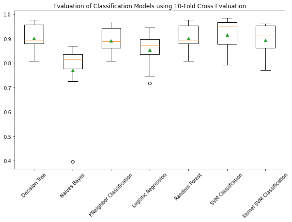

```python
# define classifiction variable globally
DT = "Decision Tree"
NB = "Naives Bayes"
KNN = "KNeighbor Classification"
LOGR = "Logistic Regression"
RF = "Random Forest"
SVMC = "SVM Classifcation"
K_SVMC = "Kernel SVM Classification"

# create list of models to evaluate and call function to evaluate models
modelsToEval = (DT, NB, KNN, LOGR, RF, SVMC, K_SVMC)
evalClassModels(modelsToEval)
```

Testing the accuracy of the algorithms produced the following results:

[output not shown]

Clearly, in this instance the training model did not perform well as there is a big difference in the accuracy scores and from the test, SVM was the best performing algorithm, not Logistic Regression.

#### *Classification algorithms run with optimal 1 feature (boat) based on RFECV with random forest and decision tree.*

Recall that both estimators produced the same optimal feature.

```python
# allocate data to X and y variables.
X = data.loc[:, ['boat']]
y = data['survived']
```

```python
# split data into training and test sets
from sklearn.model_selection import train_test_split
X_train, X_test, y_train, y_test = train_test_split( X, y, test_size = 0.25, random_state = 100)
```

```
Decision Tree Confusion Matrix:
[[139  71]
 [ 88  30]]
```

```
Decision Tree Classification Report:
              precision    recall  f1-score   support

         0.0       0.61      0.66      0.64       210
         1.0       0.30      0.25      0.27       118

    accuracy                           0.52       328
   macro avg       0.45      0.46      0.46       328
weighted avg       0.50      0.52      0.51       328





Naives Bayes Confusion Matrix:
[[190  20]
 [110   8]]
```

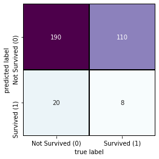

```
Naives Bayes Classification Report:
              precision    recall  f1-score   support

         0.0       0.63      0.90      0.75       210
         1.0       0.29      0.07      0.11       118

    accuracy                           0.60       328
   macro avg       0.46      0.49      0.43       328
weighted avg       0.51      0.60      0.52       328





KNeighbor Classification Confusion Matrix:
[[139  71]
 [ 88  30]]
```

```
KNeighbor Classification Classification Report:
              precision    recall  f1-score   support

         0.0       0.61      0.66      0.64       210
         1.0       0.30      0.25      0.27       118

    accuracy                           0.52       328
   macro avg       0.45      0.46      0.46       328
weighted avg       0.50      0.52      0.51       328





Logistic Regression Confusion Matrix:
[[146  64]
 [ 91  27]]
```

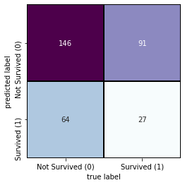

```
Logistic Regression Classification Report:
              precision    recall  f1-score   support

         0.0       0.62      0.70      0.65       210
         1.0       0.30      0.23      0.26       118

    accuracy                           0.53       328
   macro avg       0.46      0.46      0.46       328
weighted avg       0.50      0.53      0.51       328





Random Forest Confusion Matrix:
[[139  71]
 [ 88  30]]
```

```
Random Forest Classification Report:
              precision    recall  f1-score   support

         0.0       0.61      0.66      0.64       210
         1.0       0.30      0.25      0.27       118

    accuracy                           0.52       328
   macro avg       0.45      0.46      0.46       328
weighted avg       0.50      0.52      0.51       328





SVM Classifcation Confusion Matrix:
[[139  71]
 [ 88  30]]
```

```
SVM Classifcation Classification Report:
              precision    recall  f1-score   support

         0.0       0.61      0.66      0.64       210
         1.0       0.30      0.25      0.27       118

    accuracy                           0.52       328
   macro avg       0.45      0.46      0.46       328
weighted avg       0.50      0.52      0.51       328





Kernel SVM Classification Confusion Matrix:
[[146  64]
 [ 91  27]]
```

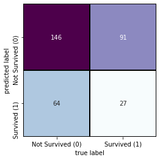

```
Kernel SVM Classification Classification Report:
              precision    recall  f1-score   support

         0.0       0.62      0.70      0.65       210
         1.0       0.30      0.23      0.26       118

    accuracy                           0.53       328
   macro avg       0.46      0.46      0.46       328
weighted avg       0.50      0.53      0.51       328
```

```python
# call function that will run classifcation algoritms
callClassFunctions(X,y)
```

Running the classification algorithms with the 1 optimal feature (boat) produced the following results.

| Algortithm | Precision | Accuracy |
| --- | --- | --- |
| Decision Tree | 61% | 52% |
| Naives Bayes | 63% | 60% |
| KNeighbor | 61% | 52% |
| Logistic Regression | 62% | 53% |
| Random Forest | 61% | 52% |
| SVM | 61% | 52% |
| Kernel SVM | 62% | 53% |

Again, none of the algortihms performed particularly well in this instance. The best performing was Naives Bayes with a precision of 63% and an accuracy of 60%.

We will now test the accuracy of the algorithms using 10-fold cross validation.

```
Mean accuracy score of classification models using 10-fold Cross-Validation:

Decision Tree:  Mean-0.922   Standard Deviation-(0.068)
Naives Bayes:  Mean-0.671   Standard Deviation-(0.043)
KNeighbor Classification:  Mean-0.921   Standard Deviation-(0.068)
Logistic Regression:  Mean-0.850   Standard Deviation-(0.061)
Random Forest:  Mean-0.922   Standard Deviation-(0.068)
SVM Classifcation:  Mean-0.918   Standard Deviation-(0.065)
Kernel SVM Classification:  Mean-0.875   Standard Deviation-(0.053)
```

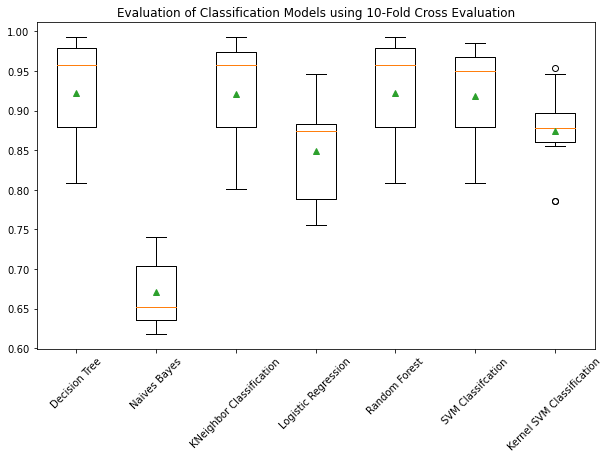

```python
# create list of models to evaluate and call function to evaluate models
modelsToEval = (DT, NB, KNN, LOGR, RF, SVMC, K_SVMC)
evalClassModels(modelsToEval)
```

Testing the accuracy of the algorithms produced the following results:

| Algortithm | Mean Accuracy | Standard Deviation |
| --- | --- | --- |
| Decision Tree | 92% | 6.8% |
| Naives Bayes | 67% | 4.3% |
| KNeighbor | 92% | 6.8% |
| Logistic Regression | 85% | 6.1% |
| Random Forest | 92% | 6.8% |
| SVM | 92% | 6.5% |
| Kernel SVM | 88% | 5.3% |

Clearly, in this instance the Naives Bayes training algorithm performed the closest to the actual test accuracy results (60% vs. 67% respectively). While the Naives Bayes was the most accurately performing algorithm, it was not the best performing as the test of the algorithm accuracies indicates that all the other training algorithms should have performed better. Had they done so, then a different training algorithm would have been the best performing.

#### *Classification algorithms run with optimal 1 feature (sex) based on RFE*

```python
# allocate data to X and y variables
X = data.loc[:, ['sex']]
y = data['survived']
```

```python
# split data into training and test sets
from sklearn.model_selection import train_test_split
X_train, X_test, y_train, y_test = train_test_split( X, y, test_size = 0.25, random_state = 100)
```

```python
# call functon that will run classifcation algoritms
callClassFunctions(X,y)
```

```
Decision Tree Confusion Matrix:
[[136  74]
 [ 81  37]]
```

```
Decision Tree Classification Report:
              precision    recall  f1-score   support

         0.0       0.63      0.65      0.64       210
         1.0       0.33      0.31      0.32       118

    accuracy                           0.53       328
   macro avg       0.48      0.48      0.48       328
weighted avg       0.52      0.53      0.52       328





Naives Bayes Confusion Matrix:
[[136  74]
 [ 81  37]]
```

```
Naives Bayes Classification Report:
              precision    recall  f1-score   support

         0.0       0.63      0.65      0.64       210
         1.0       0.33      0.31      0.32       118

    accuracy                           0.53       328
   macro avg       0.48      0.48      0.48       328
weighted avg       0.52      0.53      0.52       328





KNeighbor Classification Confusion Matrix:
[[136  74]
 [ 81  37]]
```

```
KNeighbor Classification Classification Report:
              precision    recall  f1-score   support

         0.0       0.63      0.65      0.64       210
         1.0       0.33      0.31      0.32       118

    accuracy                           0.53       328
   macro avg       0.48      0.48      0.48       328
weighted avg       0.52      0.53      0.52       328





Logistic Regression Confusion Matrix:
[[136  74]
 [ 81  37]]
```

```
Logistic Regression Classification Report:
              precision    recall  f1-score   support

         0.0       0.63      0.65      0.64       210
         1.0       0.33      0.31      0.32       118

    accuracy                           0.53       328
   macro avg       0.48      0.48      0.48       328
weighted avg       0.52      0.53      0.52       328





Random Forest Confusion Matrix:
[[136  74]
 [ 81  37]]
```

```
Random Forest Classification Report:
              precision    recall  f1-score   support

         0.0       0.63      0.65      0.64       210
         1.0       0.33      0.31      0.32       118

    accuracy                           0.53       328
   macro avg       0.48      0.48      0.48       328
weighted avg       0.52      0.53      0.52       328





SVM Classifcation Confusion Matrix:
[[136  74]
 [ 81  37]]
```

```
SVM Classifcation Classification Report:
              precision    recall  f1-score   support

         0.0       0.63      0.65      0.64       210
         1.0       0.33      0.31      0.32       118

    accuracy                           0.53       328
   macro avg       0.48      0.48      0.48       328
weighted avg       0.52      0.53      0.52       328





Kernel SVM Classification Confusion Matrix:
[[136  74]
 [ 81  37]]
```

```
Kernel SVM Classification Classification Report:
              precision    recall  f1-score   support

         0.0       0.63      0.65      0.64       210
         1.0       0.33      0.31      0.32       118

    accuracy                           0.53       328
   macro avg       0.48      0.48      0.48       328
weighted avg       0.52      0.53      0.52       328
```

Running the classification algorithms with the 1 optimal feature (sex) produced the same results across all the algorithms.

| Algortithm | Precision | Accuracy |
| --- | --- | --- |
| Decision Tree | 63% | 53% |
| Naives Bayes | 63% | 53% |
| KNeighbor | 63% | 53% |
| Logistic Regression | 63% | 53% |
| Random Forest | 63% | 53% |
| SVM | 63% | 53% |
| Kernel SVM | 63% | 53% |

In this case, we are not able to distinguish which algorithm is the best performing.

We will now test the accuracy of the algorithms using 10-fold cross validation.

```
Mean accuracy score of classification models using 10-fold Cross-Validation:

Decision Tree:  Mean-0.780   Standard Deviation-(0.057)
Naives Bayes:  Mean-0.780   Standard Deviation-(0.057)
KNeighbor Classification:  Mean-0.610   Standard Deviation-(0.081)
Logistic Regression:  Mean-0.780   Standard Deviation-(0.057)
Random Forest:  Mean-0.780   Standard Deviation-(0.057)
SVM Classifcation:  Mean-0.780   Standard Deviation-(0.057)
Kernel SVM Classification:  Mean-0.780   Standard Deviation-(0.057)
```

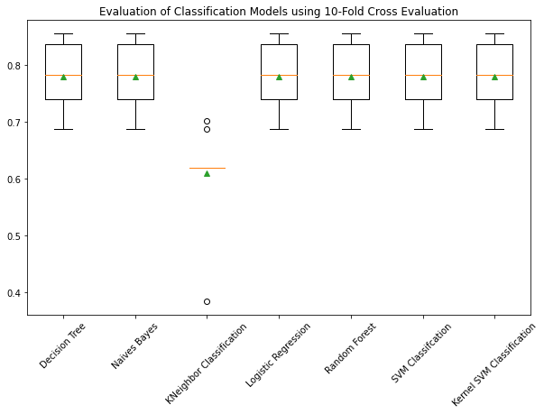

```python
# create list of models to evaluate and call function to evaluate models
modelsToEval = (DT, NB, KNN, LOGR, RF, SVMC, K_SVMC)
evalClassModels(modelsToEval)
```

Testing the accuracy of the algorithms produced the following results:

| Algortithm | Mean Accuracy | Standard Deviation |
| --- | --- | --- |
| Decision Tree | 78% | 5.7% |
| Naives Bayes | 78% | 5.7% |
| KNeighbor | 61% | 8.1% |
| Logistic Regression | 78% | 5.7% |
| Random Forest | 78% | 5.7% |
| SVM | 78% | 5.7% |
| Kernel SVM | 78% | 5.7% |

#### *Classification algorithms run with all the features*

```python
# allocate data to X and y variables
X = data.drop('survived',axis=1).astype(float)
y = data['survived']
```

```python
# split data into training and test sets
from sklearn.model_selection import train_test_split
X_train, X_test, y_train, y_test = train_test_split( X, y, test_size = 0.25, random_state = 100)
```

```
Decision Tree Confusion Matrix:
[[125  85]
 [ 80  38]]
```

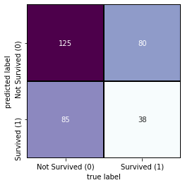

```
Decision Tree Classification Report:
              precision    recall  f1-score   support

         0.0       0.61      0.60      0.60       210
         1.0       0.31      0.32      0.32       118

    accuracy                           0.50       328
   macro avg       0.46      0.46      0.46       328
weighted avg       0.50      0.50      0.50       328





Naives Bayes Confusion Matrix:
[[151  59]
 [ 83  35]]
```

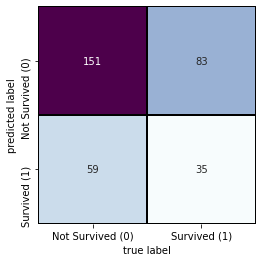

```
Naives Bayes Classification Report:
              precision    recall  f1-score   support

         0.0       0.65      0.72      0.68       210
         1.0       0.37      0.30      0.33       118

    accuracy                           0.57       328
   macro avg       0.51      0.51      0.51       328
weighted avg       0.55      0.57      0.55       328





KNeighbor Classification Confusion Matrix:
[[129  81]
 [ 80  38]]
```

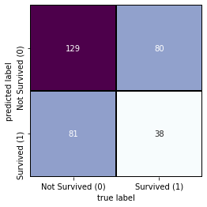

```
KNeighbor Classification Classification Report:
              precision    recall  f1-score   support

         0.0       0.62      0.61      0.62       210
         1.0       0.32      0.32      0.32       118

    accuracy                           0.51       328
   macro avg       0.47      0.47      0.47       328
weighted avg       0.51      0.51      0.51       328





Logistic Regression Confusion Matrix:
[[138  72]
 [ 83  35]]
```

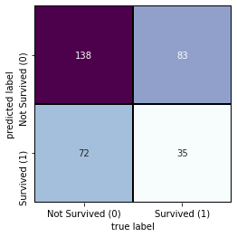

```
Logistic Regression Classification Report:
              precision    recall  f1-score   support

         0.0       0.62      0.66      0.64       210
         1.0       0.33      0.30      0.31       118

    accuracy                           0.53       328
   macro avg       0.48      0.48      0.48       328
weighted avg       0.52      0.53      0.52       328





Random Forest Confusion Matrix:
[[130  80]
 [ 84  34]]
```

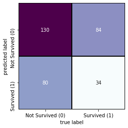

```
Random Forest Classification Report:
              precision    recall  f1-score   support

         0.0       0.61      0.62      0.61       210
         1.0       0.30      0.29      0.29       118

    accuracy                           0.50       328
   macro avg       0.45      0.45      0.45       328
weighted avg       0.50      0.50      0.50       328





SVM Classifcation Confusion Matrix:
[[143  67]
 [ 87  31]]
```

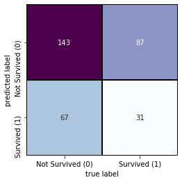

```
SVM Classifcation Classification Report:
              precision    recall  f1-score   support

         0.0       0.62      0.68      0.65       210
         1.0       0.32      0.26      0.29       118

    accuracy                           0.53       328
   macro avg       0.47      0.47      0.47       328
weighted avg       0.51      0.53      0.52       328





Kernel SVM Classification Confusion Matrix:
[[144  66]
 [ 89  29]]
```

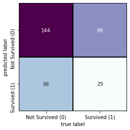

```
Kernel SVM Classification Classification Report:
              precision    recall  f1-score   support

         0.0       0.62      0.69      0.65       210
         1.0       0.31      0.25      0.27       118

    accuracy                           0.53       328
   macro avg       0.46      0.47      0.46       328
weighted avg       0.51      0.53      0.51       328
```

```python
# call functon that will run classifcation algoritms
callClassFunctions(X,y)
```

Running the classification algorithms with the all the features produced the following results.

| Algortithm | Precision | Accuracy |
| --- | --- | --- |
| Decision Tree | 61% | 50% |
| Naives Bayes | 65% | 57% |
| KNeighbor | 62% | 51% |
| Logistic Regression | 62% | 53% |
| Random Forest | 61% | 50% |
| SVM | 62% | 53% |
| Kernel SVM | 62% | 53% |

Again, none of the algortihms performed particularly well in this instance. The best performing was Naives Bayes with a precision of 65% and an accuracy of 57%.

We will now test the accuracy of the algorithms using 10-fold cross validation.

```
Mean accuracy score of classification models using 10-fold Cross-Validation:

Decision Tree:  Mean-0.862   Standard Deviation-(0.067)
Naives Bayes:  Mean-0.790   Standard Deviation-(0.082)
KNeighbor Classification:  Mean-0.837   Standard Deviation-(0.072)
Logistic Regression:  Mean-0.843   Standard Deviation-(0.062)
Random Forest:  Mean-0.891   Standard Deviation-(0.066)
SVM Classifcation:  Mean-0.873   Standard Deviation-(0.060)
Kernel SVM Classification:  Mean-0.885   Standard Deviation-(0.057)
```

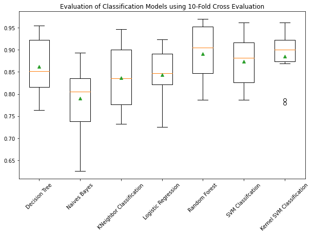

```python
# create list of models to evaluate and call function to evaluate models
modelsToEval = (DT, NB, KNN, LOGR, RF, SVMC, K_SVMC)
evalClassModels(modelsToEval)
```

Testing the accuracy of the algorithms produced the following results:

[output not shown]

None of the training algorithms performed will in this case. The training algorithms accuracy scores was far from the test of the accuracy score results. From the test accuracy scores, Kernel SVM or Random Forest should have performed the best, but they didn't.

#### *Classification algorithms run based in PSA dimension of 5*

```python
# allocate data to X and y variables
X = X_pca5
y = data['survived']
```

```python
# split data into training and test sets
from sklearn.model_selection import train_test_split
X_train, X_test, y_train, y_test = train_test_split( X, y, test_size = 0.25, random_state = 100)
```

```
Decision Tree Confusion Matrix:
[[127  83]
 [ 76  42]]
```

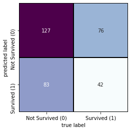

```
Decision Tree Classification Report:
              precision    recall  f1-score   support

         0.0       0.63      0.60      0.62       210
         1.0       0.34      0.36      0.35       118

    accuracy                           0.52       328
   macro avg       0.48      0.48      0.48       328
weighted avg       0.52      0.52      0.52       328





Naives Bayes Confusion Matrix:
[[180  30]
 [102  16]]
```

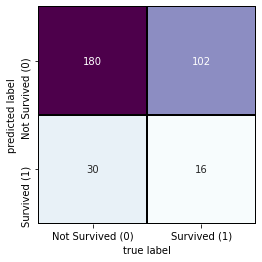

```
Naives Bayes Classification Report:
              precision    recall  f1-score   support

         0.0       0.64      0.86      0.73       210
         1.0       0.35      0.14      0.20       118

    accuracy                           0.60       328
   macro avg       0.49      0.50      0.46       328
weighted avg       0.53      0.60      0.54       328





KNeighbor Classification Confusion Matrix:
[[131  79]
 [ 82  36]]
```

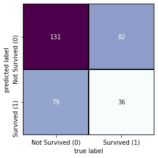

```
KNeighbor Classification Classification Report:
              precision    recall  f1-score   support

         0.0       0.62      0.62      0.62       210
         1.0       0.31      0.31      0.31       118

    accuracy                           0.51       328
   macro avg       0.46      0.46      0.46       328
weighted avg       0.51      0.51      0.51       328





Logistic Regression Confusion Matrix:
[[145  65]
 [ 89  29]]
```

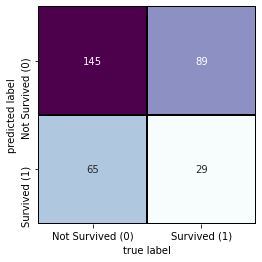

```
Logistic Regression Classification Report:
              precision    recall  f1-score   support

         0.0       0.62      0.69      0.65       210
         1.0       0.31      0.25      0.27       118

    accuracy                           0.53       328
   macro avg       0.46      0.47      0.46       328
weighted avg       0.51      0.53      0.52       328





Random Forest Confusion Matrix:
[[132  78]
 [ 82  36]]
```

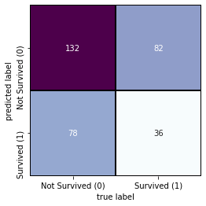

```
Random Forest Classification Report:
              precision    recall  f1-score   support

         0.0       0.62      0.63      0.62       210
         1.0       0.32      0.31      0.31       118

    accuracy                           0.51       328
   macro avg       0.47      0.47      0.47       328
weighted avg       0.51      0.51      0.51       328





SVM Classifcation Confusion Matrix:
[[144  66]
 [ 87  31]]
```

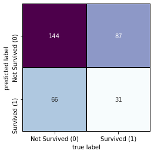

```
SVM Classifcation Classification Report:
              precision    recall  f1-score   support

         0.0       0.62      0.69      0.65       210
         1.0       0.32      0.26      0.29       118

    accuracy                           0.53       328
   macro avg       0.47      0.47      0.47       328
weighted avg       0.51      0.53      0.52       328





Kernel SVM Classification Confusion Matrix:
[[144  66]
 [ 88  30]]
```

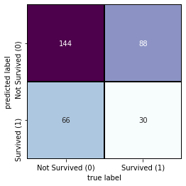

```
Kernel SVM Classification Classification Report:
              precision    recall  f1-score   support

         0.0       0.62      0.69      0.65       210
         1.0       0.31      0.25      0.28       118

    accuracy                           0.53       328
   macro avg       0.47      0.47      0.47       328
weighted avg       0.51      0.53      0.52       328
```

```python
# call functon that will run classifcation algoritms
callClassFunctions(X,y)
```

Running the classification algorithms based on PCA with dimension of 5 produced the following results.

[output not shown]

Again, none of the algortihms performed particularly well in this instance. The best performing was Naives Bayes with a precision of 64% and an accuracy of 60%.

We will now test the accuracy of the algorithms using 10-fold cross validation.

```
Mean accuracy score of classification models using 10-fold Cross-Validation:

Decision Tree:  Mean-0.843   Standard Deviation-(0.055)
Naives Bayes:  Mean-0.702   Standard Deviation-(0.045)
KNeighbor Classification:  Mean-0.840   Standard Deviation-(0.070)
Logistic Regression:  Mean-0.862   Standard Deviation-(0.060)
Random Forest:  Mean-0.893   Standard Deviation-(0.069)
SVM Classifcation:  Mean-0.875   Standard Deviation-(0.062)
Kernel SVM Classification:  Mean-0.881   Standard Deviation-(0.054)
```

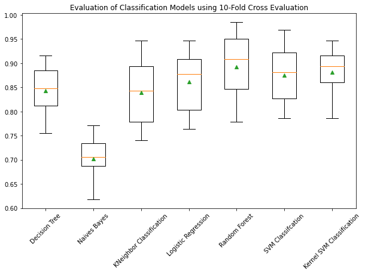

```python
# create list of models to evaluate and call function to evaluate models
modelsToEval = (DT, NB, KNN, LOGR, RF, SVMC, K_SVMC)
evalClassModels(modelsToEval)
```

Testing the accuracy of the algorithms produced the following results:

[output not shown]

None of the training algorithms performed will in this case. The training algorithms accuracy scores were far from the test of the accuracy score results. From the test accuracy scores, Random Forest should have performed the best, but they didn't.